# Word Clouds

Kimberly Staudt

2017-11-01

## What is a Word Cloud?

A word cloud is an image composed of words whose size is determined by the frequency in which they appear. Today, we will be creating a word cloud from the Tame Impala album, Currents. First, create a word text file, and save the lyrics (no titles) in that file. Save both this file and a new R script file in the same directory. Now we can begin.

```r
lines<-scan('currents album.txt',what=character(),sep='\n')
```

Run head(lines) to view the the first several rows of the matrix/data frame. You can also use tail(lines) to view the last rows.

```r
lines_df<-data_frame(line=1:407,text=lines)
```

Now, use unnest_tolkens() to create a new column, word, from text. Store this into the data frame, words_df

```r
words_df<-lines_df%>%
  unnest_tokens(word,text)
```

Common words can clutter our word cloud. Filter these out with **%in%** . This compares the word column in words dataframe to the word column in the stop_words dataframe. Use the ! symbol to stop common words. Store back into words_df.

```r
words_df<-words_df%>%
  filter(!(word %in% stop_words$word))
```

Next,group by the word column. Use summarise to count the number of times the the appears. Store as word_freq.

```r
word_freq<-words_df%>%
  group_by(word)%>%
  summarise(count=n())
```

We are now ready to finalize our wordcloud. View pallete colors with the display.brewer.all() function. We are going to select the word and count column in word_freq. Our color pallete today is called Set2.

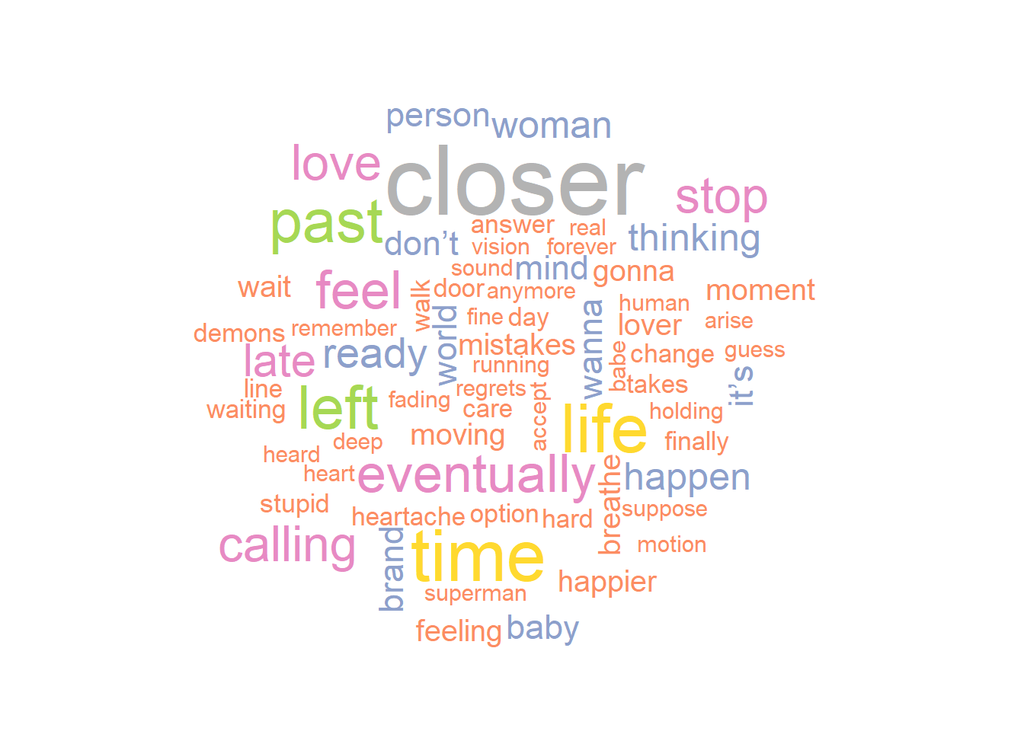

```r
wordcloud(word_freq$word,word_freq$count,color=brewer.pal(24, 'Set2'))
```